# R Notebook

Distribution

- a list of all the possible outcomes of a random variable along with either
  - their probability of occuring [probability distribution]
  - their frequency of occuring [frequency distribution]

a way of communicating how often or how likely something occurs/is to occur

```r
library(tidyverse)
source("../../Day_1/Probability/prob.R")
```

| toss1 | p |
| --- | --- |
| H | 0.5 |
| T | 0.5 |

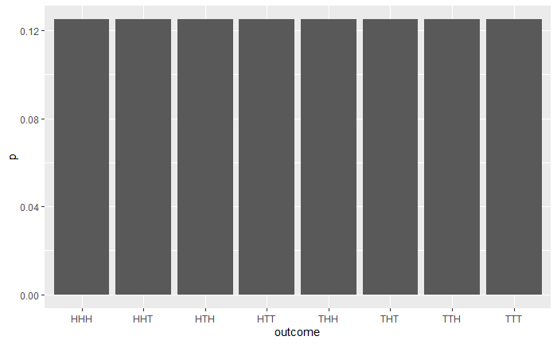

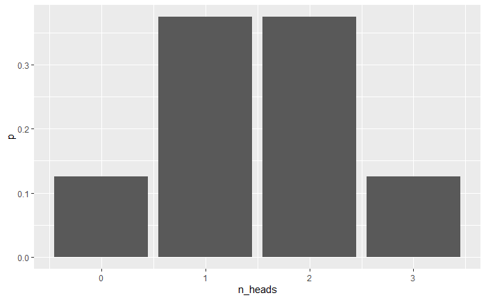

Probability distribution ^ We woudl call this a discrete probability districution (finite/countable)

General properties of discrete probability distributions

x-axis = outcomes y-axis = probability the probabilities must sum to 1

$$\sum{p(x)} = 1$$

## Measures of centrality

-mean -median -mode

These are all expressing where the centre of the distribution is. They are different measures of the middle of a distribution.

```r
library(janitor)
library(lubridate)
```

```r
air_con_sales <- read_csv("AirConSales.csv")
```

```r
air_con_clean <- air_con_sales %>%
  clean_names() %>%
  mutate(date = mdy(date))
```

For every date, we’ve got how many air conditioners were sold. We’re interested, though, in how often it is to sell a certain number of ACs.

e.g. how often / how likely is it that on any day we sell 3 ACs?

```r
sales_freqs <- air_con_clean %>%
  tabyl(units_sold)
```

percet here doesn’t refer to a probability / percent but a relative requency (which is subtley different)

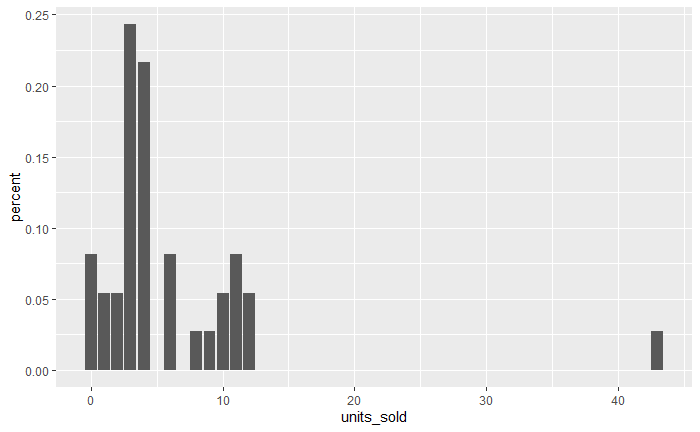

```r
sales_freqs %>%
  ggplot() +
  aes(units_sold, percent) +
  geom_col()
```

Mean

- Commonly incorrectly referred to as the average

sum of the values / n o values

$\mu$ = a population $\bar{x}$ = a sample

```r
air_con_clean %>%
  summarise(mean_daily_sales = mean(units_sold))
```

| mean_daily_sales |
| --- |
| 5.945946 |

Median

middle value if we sorted the values in the list

```r
air_con_clean %>%
  summarise(mean_daily_sales = mean(units_sold),
            median = median(units_sold))
```

| mean_daily_sales | median |
| --- | --- |
| 5.945946 | 4 |

Mode - the most commonly occuring value / the most likely value in the data

- sadly there’s no stats mode fuction, we need to make our own

```r
# let's make our mode function
get_mode <- function(data){

  tabled_data <- table(data)
  table_names <- names(tabled_data)

  return( table_names[tabled_data == max(tabled_data)] )

}
```

```r
air_con_clean %>%
  summarise(mean_daily_sales = mean(units_sold),
            median = median(units_sold),
            mode = get_mode(units_sold))
```

| mean_daily_sales | median | mode |
| --- | --- | --- |
| 5.945946 | 4 | 3 |

We can express skew numerically

```r
library(e1071)
```

When quantifying skew we can use the following class table

| magnitude | classification |
| --- | --- |
| <0.5 | fairly symmetric |
| 0.5 - 1.0 | moderately skewed |
| > 1.0 | highly skewed |

| direction | classification |
| --- | --- |
| negative | left skew |
| positive | right skew |

```r
air_con_clean %>%
  summarise(
    skew = skewness(units_sold, type = 1)
  )
```

| skew |
| --- |
| 3.824317 |

## Measures of spread

-Range -IQR -Box plots -Variance -Standard deviation

What does our distribution look like? How far apart are the values typically? Is it a very narrow and tall distribution, or is it more wide and short?

```r
jobs <- read_csv("TyrellCorpJobs.csv") %>%
  select(-1) %>%
  clean_names()
```

```
* `` -> ...1
```

```r
jobs %>%
  summarise(range = diff(range(salary)))
```

| range |
| --- |
| 61568 |

```r
summary(jobs)
```

```
   position             salary
 Length:175         Min.   :29459
 Class :character   1st Qu.:33039
 Mode  :character   Median :35009
                    Mean   :39383
                    3rd Qu.:41990
                    Max.   :91027
```

Remember to visualise the distribution first before calculating stats!

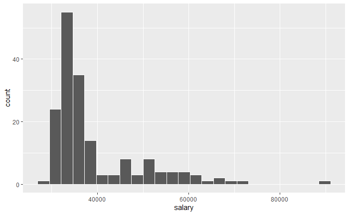

```r
jobs %>%
  ggplot(aes(x = salary))+
  geom_histogram(col = "white", bins = 25)
```

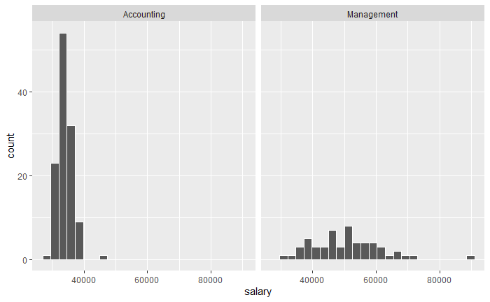

```r
jobs %>%
  ggplot(aes(x = salary))+
  geom_histogram(col = "white", bins = 25) +
  facet_wrap(~position)
```

So there is strong evidence of bimodality. From now on, consider the two distributions (one for each position)

```r
jobs %>%
  group_by(position) %>%
  summarise(range = diff(range(salary)))
```

| position | range |
| --- | --- |
| Accounting | 15535 |
| Management | 59366 |

There is more salary disparity in management than in accounting

Range is heavily effected by extreme values (most accounting salaries are between 30 and 40k - the range suggests a spread of 15K (50% more))

Less influenced by outliers is the Interquartile range

Interquartile range

| position | q1 | q2 | q3 | iqr | iqr_from_stats |
| --- | --- | --- | --- | --- | --- |
| Accounting | 32390.5 | 34150 | 35265.0 | 2874.5 | 2874.5 |
| Management | 43698.0 | 50300 | 57288.5 | 13590.5 | 13590.5 |

```r
library(skimr)
```

```r
jobs %>% group_by(position) %>%
  skim()
```

```
-- Data Summary ------------------------
                           Values
Name                       Piped data
Number of rows             175
Number of columns          2
_______________________
Column type frequency:
  numeric                  1
________________________
Group variables            position
```

|  | skim_variable | position | n_missing | complete_rate | mean | sd | p0 | p25 | p50 | p75 | p100 | hist |
| --- | --- | --- | --- | --- | --- | --- | --- | --- | --- | --- | --- | --- |
| 1 | salary | Accounting | 0 | 1 | 34115.02 | 2383.676 | 29459 | 32390.5 | 34150 | 35265.0 | 44994 |  |
| 2 | salary | Management | 0 | 1 | 50876.15 | 10940.555 | 31661 | 43698.0 | 50300 | 57288.5 | 91027 |  |

a more graphical view of quartiles: Box plots

```r
jobs %>%
  group_by(position) %>%
  summarise(
    q1 = quantile(salary, 0.25),
    q2 = quantile(salary, 0.5),
    q3 = quantile (salary, 0.75),
    iqr = q3 - q1,
    iqr_from_stats = IQR(salary),
    outlier_distance = 1.5 * iqr
  )
```

| position | q1 | q2 | q3 | iqr | iqr_from_stats | outlier_distance |
| --- | --- | --- | --- | --- | --- | --- |
| Accounting | 32390.5 | 34150 | 35265.0 | 2874.5 | 2874.5 | 4311.75 |
| Management | 43698.0 | 50300 | 57288.5 | 13590.5 | 13590.5 | 20385.75 |

```r
NA
NA
```

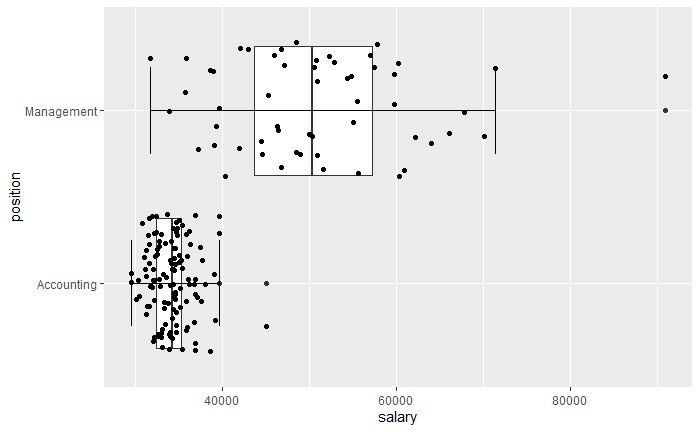

```r
jobs %>%
  ggplot() +
  aes(x = salary, y = position) +
  geom_boxplot()+
  geom_jitter() +
  stat_boxplot(geom = "errorbar", width = 0.5)
```

Task: 10 mins Investigate and comment on the centrality and spreads of distribution_1 and distribution_2 produced by the following function calls. Use geom_boxplot() and skim() first Next, plot histograms to confirm your descriptions. [Don’t worry about what the functions generating distribution_1 and distribution_2 are doing]

```r
set.seed(42)
distribution_1 <- tibble(
  y = append(rnorm(n = 100, mean = 5, sd = 10), rnorm(n = 200, mean = 5, sd = 1))
)

distribution_2 <- tibble(
  y = runif(n = 1000, min = -30, max = 30)
)
```

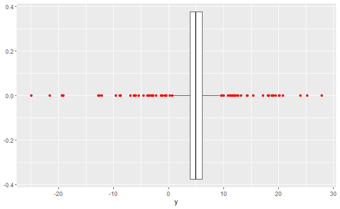

```r
distribution_1 %>%
  ggplot(aes(x = y)) +
  geom_boxplot(outlier.colour = "red")
```

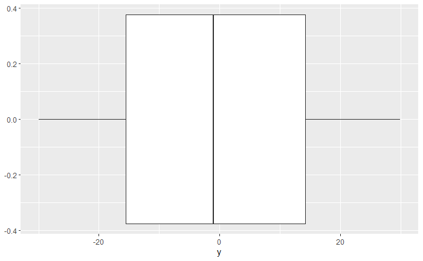

```r
distribution_2 %>%
  ggplot(aes(x = y)) +
  geom_boxplot()
```

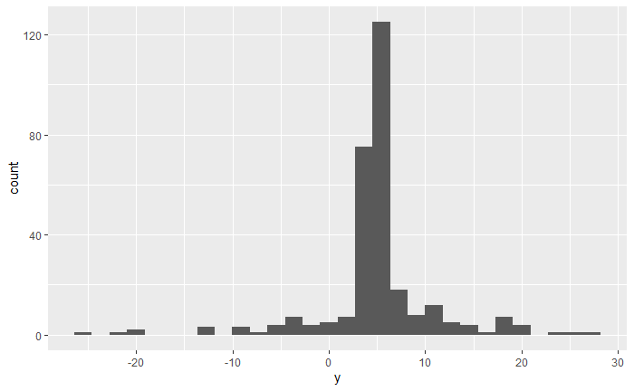

```r
distribution_1 %>%
  ggplot(aes(x = y)) +
  geom_histogram()
```

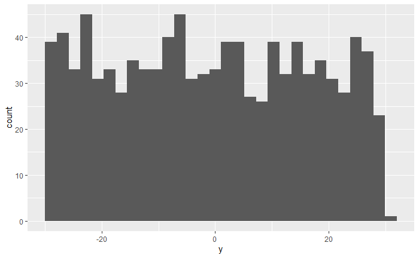

```r
distribution_2 %>%
  ggplot(aes(x = y)) +
  geom_histogram()
```

```r
distribution_1 %>%
  skim()
```

```
-- Data Summary ------------------------
                           Values
Name                       Piped data
Number of rows             300
Number of columns          1
_______________________
Column type frequency:
  numeric                  1
________________________
Group variables            None
```

|  | skim_variable | n_missing | complete_rate | mean | sd | p0 | p25 | p50 | p75 | p100 | hist |
| --- | --- | --- | --- | --- | --- | --- | --- | --- | --- | --- | --- |
| 1 | y | 0 | 1 | 5.075765 | 6.045745 | -24.9309 | 3.945366 | 4.976071 | 6.115762 | 27.86645 |  |

```r
distribution_2 %>%
  skim()
```

```
-- Data Summary ------------------------
                           Values
Name                       Piped data
Number of rows             1000
Number of columns          1
_______________________
Column type frequency:
  numeric                  1
________________________
Group variables            None
```

|  | skim_variable | n_missing | complete_rate | mean | sd | p0 | p25 | p50 | p75 | p100 | hist |
| --- | --- | --- | --- | --- | --- | --- | --- | --- | --- | --- | --- |
| 1 | y | 0 | 1 | -0.7187298 | 17.32224 | -29.92365 | -15.48538 | -0.9870809 | 14.17994 | 29.96274 |  |

| skew |
| --- |
| 0.02866984 |

```r
heavily_right_skewed <- read_csv("heavily_right_skewed.csv")
```

```
* `` -> ...1
```

| skew |
| --- |
| 1.408127 |

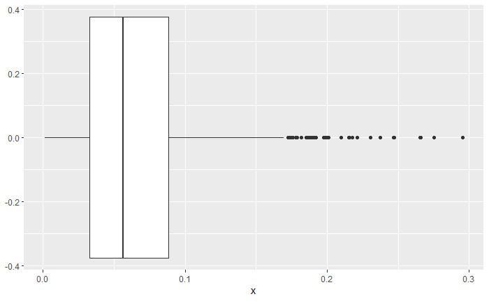

```r
heavily_right_skewed %>%
  skim()
```

```
-- Data Summary ------------------------
                           Values
Name                       Piped data
Number of rows             1000
Number of columns          2
_______________________
Column type frequency:
  numeric                  2
________________________
Group variables            None
```

|  | skim_variable | n_missing | complete_rate | mean | sd | p0 | p25 | p50 | p75 | p100 | hist |
| --- | --- | --- | --- | --- | --- | --- | --- | --- | --- | --- | --- |
| 1 | ...1 | 0 | 1 | 500.50000000 | 288.81943610 | 1.000000000 | 250.75000000 | 500.50000000 | 750.25000000 | 1000.0000000 |  |
| 2 | x | 0 | 1 | 0.06516195 | 0.04455074 | 0.001483156 | 0.03290218 | 0.05624313 | 0.08819214 | 0.2955159 |  |

## Variance

A single number value for a measure of spread

a measure of how far each value in the dataset is from the mean

```r
set.seed(42)

londoner_weights <- tibble(
  marathoners = rnorm(50, mean = 68, sd = 0.5),
  commuters = rnorm(50, mean = 68, sd = 5)
) %>%
  pivot_longer(cols = everything(), names_to = "group", values_to = "weight")

ggplot(londoner_weights) +
  aes(x = weight, y = group) +
  geom_boxplot()

londoner_weights %>%
  group_by(group) %>%
  summarise(mean_weight = mean(weight),
            var_weight = var(weight),
            sd_weight = sd(weight),
            sd_weight_long = sqrt(var_weight))
```

[output not shown]

If weight is in KG, variance will be in KG^2

St dev = sqrt(variance), so it is in the same units as whatever is being measured in the column.

Calculating variance longhand

Task - 5 mins

Calculate the variance and standard deviation for the salaries in accounting and management at tyrell corp and comment on the standard deviations

```r
jobs %>%
  group_by(position) %>%
  summarise(mean_salary = mean(salary),
            var_salary = var(salary),
            sd_salary = sd(salary))
```

| position | mean_salary | var_salary | sd_salary |
| --- | --- | --- | --- |
| Accounting | 34115.02 | 5681909 | 2383.676 |
| Management | 50876.15 | 119695746 | 10940.555 |

The standard deviation for accounting salaries is 2383.68, meaning that on average, salaries in accounting vary by £2383.68 from the mean. The standard deviation for management salaries is 10940.56, meaning that on average, salaries in management vary by £10940.56 from the mean. This means that the spread of management salaries should be wider, whereas accounting salaries will be more clustered around the mean (b/c they don’t vary as much.)

## Common distributions

LOs -Understand the concepts of probability mass function and probability density fuctions -Be familiar with some common distribution functions -Understand that many things are normally distributed -Know some examples of normally distributed quantities -Understand variance and standard deviation for a standard normal distribution -Be able to use distributions to canculate parameters of a normal distribution -Know about the empirical 3 sigma rule for a normal distribution

Discrete and continuous variables

Numeric data - discrete / continuous Categorical data - nominal / ordinal (they have an order)

Discrete - countable and finite Continuous - uncountable

Variables

Number of people in my survey who love the colour blue = discrete value height of people in Scotland = continuous scale (no point value to represent their height)

age - continuous numeric age group (child, adult, senior) - ordinal number of people in household - discrete height - continuous numeric weight - continuous numeric shoe size (uk) - ordinal foot size - continuous numeric vegetarian - nominal categoric (binary)

## Probability mass and probability density functions

discrete probability distribution is a probability distribution of a discrete variable

heads or tals, discrete number of outcomes

probability mass function - probability distrubution of a discrete variable

probability density function - probability distribution of a continuous variable

What is the probability of heights in the range from 174.22cm to 178.91cm in the dataset) Based on this data what is the probability that I measure someone’s height in the range of 174.22cm to 178.91cm?

In the case of pmf vs pdf, while we can measure probabilities for specific discrete values of a pmf, we can’t for a pdf. We look instead at the probability of a range of values.

*Rules for discrete probability distributions*

-outcome is the x axis -y is our probability of that outcome occurring (pmfs) -the sum of all probabilities must be 1 -each probability must be between 0 and 1

*Rules for continuous probability distributions*

-outcome is the x axis -y is the probability density -the sum of all probabilities must be 1 (the area under the curve defined by the probability density function must be 1) -probabilities are area under the curve -> the probability of a value being within a certain range is the area under the curve from x = lower to x = higher -the probability of a value in the range or x = x_min to x = x_max must be 1

Discrete distributions

Discrete uniform

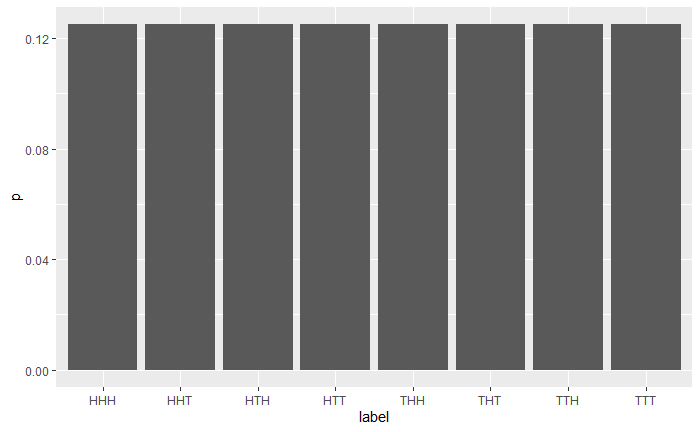

```r
tosscoin(3) %>%
  mutate(label = str_c(toss1, toss2, toss3, sep = "")) %>%
  mutate(p = 1/n()) %>%
  ggplot(aes(label, p))+
  geom_col()
```

There is another way we can explore probability distributions

via Cumulative distribution functions

F(1) = 1/6 = p(1 or less) F(2) = 1/6 + 1/6 = p(2 or less)

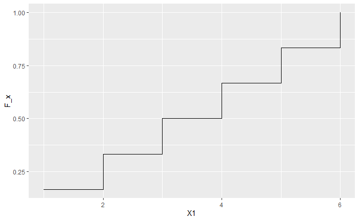

Getting individual probabilities from cdfs

Continuous distributions

Continuous uniform

length of “brain breaks” at CodeClan were monitored for a week. They were found to be distributed unifomly (equal p for all outcomes) between 5 minutes and 22 minutes.

l is continuous

l could be 7.18233333, it could be 5 minutes, it could be 21.9 minutes

What will the probability density function look like for the random variable l?

useful distribution functions

p - cumulative density function q - quantile r - random numbers d - distribution

rnorm()

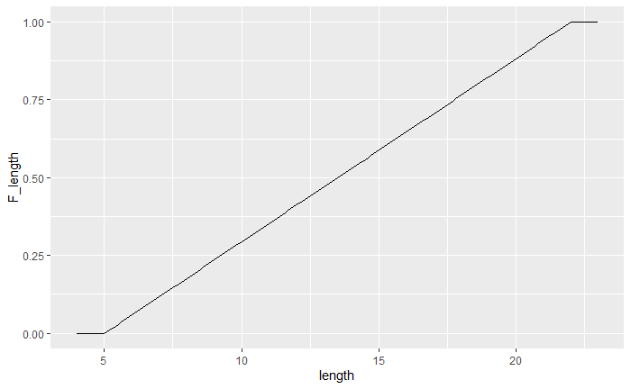

What is the probability of a brain break lasting between 8.4 and 10.7 minutes?

```r
f_10_7 - f_8_4
```

```
[1] 0.1352941
```

14% chance of seeing a brain break between 8.4 and 10.7 minutes long

What does this look like on our initial plot?

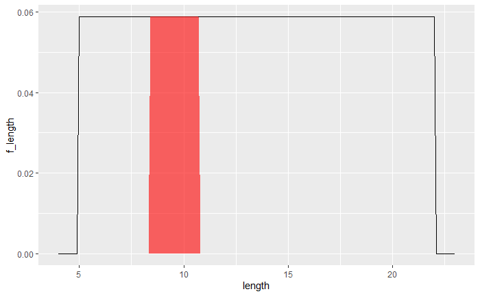

```r
(10.7 - 8.4) * max(brain_breaks$f_length)
```

```
[1] 0.1352941
```

Normal Distribution

very prevalent in nature if you took 1000 measurements of people’s head size –> normal distribution if you took 1000 measurements of penguin flipper widths –> normal distribution

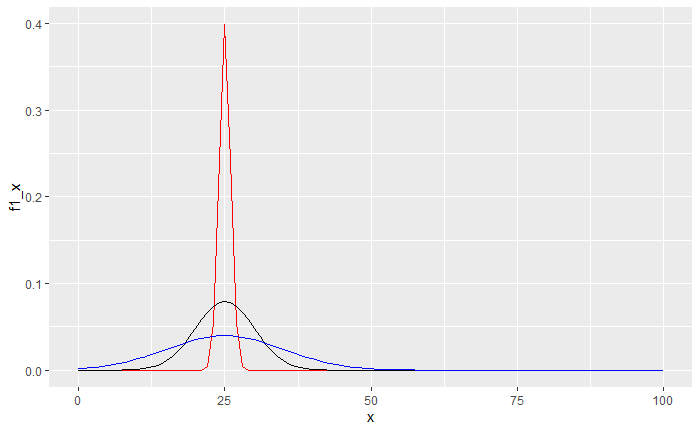

```r
three_norms <- tibble(
  x = seq(0, 100, 1),
  f1_x = dnorm(x = x, mean = 25, sd = 1),
  f2_x = dnorm(x = x, mean = 25, sd = 5),
  f3_x = dnorm(x = x, mean = 25, sd = 10)
)

three_norms %>%
  ggplot() +
  geom_line(aes(x = x, f1_x), col = "red") +
  geom_line(aes(x = x, f2_x), col = "black") +
  geom_line(aes(x = x, f3_x), col = "blue")
```

Notice that for very small values of x (or very distant from the mean) for a normal distribution these will be non-zero. They’ll be extremely small values, but not p = 0

Much of what we see when it comes to inferential stats (tomorrow and thursday) is that taking repeated samples of a population leads to a normal distribution.

As well as physical properties, stock volatilities, travel times.

Quantities tend to be normally distributed when they are composed of smaller randomly distributed properties.

How can we tell if our data is normally distributed? qqplot(quantile quantile plots) various normality tests

Look at the normal distribution vs our data (fitting a normal distribution to a data set)

Looking at just he accounting department, is the data normally distributed?

| num | mean_sal | sd_sal |
| --- | --- | --- |
| 120 | 34115.02 | 2383.676 |

Overlaying a normal distribution

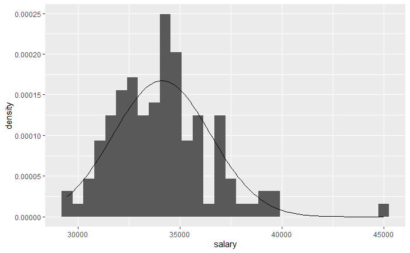

```r
jobs %>%
  filter(position == "Accounting") %>%
  ggplot(aes(x = salary)) +
  geom_histogram(aes(y = ..density..))+
  stat_function(
    fun = ~dnorm(.,mean = accounting_position_stats$mean_sal,
                 sd = accounting_position_stats$sd_sal)

  )
```

```r
shapiro.test(rnorm(100, mean = 5, sd = 3))
```

```
    Shapiro-Wilk normality test

data:  rnorm(100, mean = 5, sd = 3)
W = 0.98732, p-value = 0.4595
```

“Standard Normal”

scaled so that mean = 0, sd = 1

standardised variable (tool to describe normal distributions)

z = value - mean / sd

Tells us how far away we are from the mean in units of standard deviation

So if z = 1.3, then the value is 1.3 * sd away from the mean value z = 3 would be a value 3 * sd away from the mean

This is another definition of an outlier

-a value 1.5*IQR above Q3 or below Q1 -Any value with a z above or below 3

```r
management_scaled <- jobs %>%
  filter(position == "Management") %>%
  #scale automatically calculates z scores
  mutate(z_salary = scale(salary)) %>%
  mutate(mean_sal = mean(salary))

management_scaled %>%
  filter(abs(z_salary) > 2)
```

| position | salary | z_salary | mean_sal |
| --- | --- | --- | --- |
| Management | 91027 | 3.66991 | 50876.15 |

Standard Normal

scaled so that mean = 0, sd = 1

Shading the standard normal (in notes)

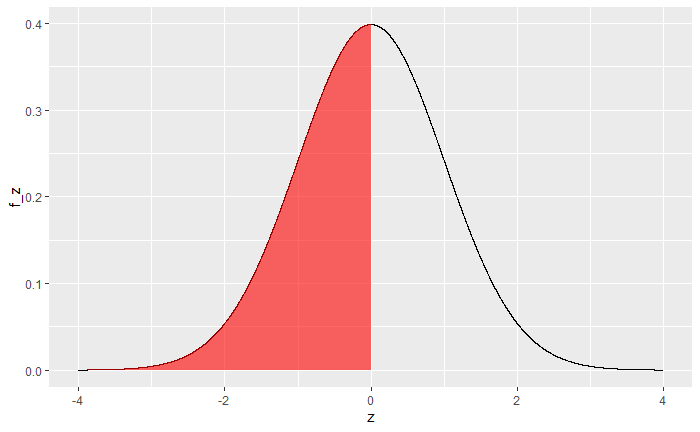

```r
# SLACK THIS OUT
shade_standard_normal <- function(shade_from, shade_to){
  standard_normal <- tibble(
    z = seq(from = -4, to = 4, by = 0.001),
    f_z = dnorm(x = z)
  )
  standard_normal %>%
    ggplot(aes(x = z, y = f_z)) +
    geom_line() +
    geom_ribbon(aes(ymin = 0, ymax = ifelse(z >= shade_from & z <= shade_to, f_z, 0)), fill = "red", alpha = 0.6)
}

shade_standard_normal(shade_from = -Inf, shade_to = 0)
```

The empirical 3-sigma rule

Most values lie within 3 standard deviations of the mean. If using 99% CI If using 95% CI, they will lie within 2 standard deviations

Let’s calculate how many values should lie within 1 sd of the mean for a standard normal distribution

```r
100 * (pnorm(q = 1) - pnorm(q = -1))
```

```
[1] 68.26895
```

68% of the data should lie within 1 standard deviation of the mean.

```r
100 * (pnorm(q = 2) - pnorm(q = -2))
```

```
[1] 95.44997
```

95% of the data shoudl lie within 2 standard deviations of the mean

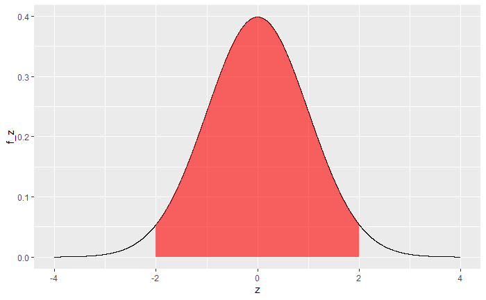

This is called the empirical 3 sigma rule

For data that is normally distributed we expect

```
68% of values lie within 1 sd of mean
95% of values lie within 2 sd of mean
99.7% of values lie within 3 sd of mean
```